# Simple Linear Regression: In Class Exercise

Jiyeong Pyo

2025-10-08

Welcome to an in class exercise on simple linear regression!

```r
library(tidyverse)
```

Let’s clean up our environment.

```r
rm(list = ls())
```

#### Yale Program on Climate Communication

Now you should read in the climate belief data (climate.csv) from the Yale Program on Climate Communication: https://climatecommunication.yale.edu/visualizations-data/ycom-us/.

You will work with the variables: GW = global warming. **geotype** the unit of observation (e.g., county, state, etc..) **geoid** ID for each county **geoname** Name of each county **gwvoteimp** Estimated percentage who say a candidate’s views on GW are important to their vote **priority** Estimated percentage who say global warming should be a high priority for the next president and Congress

In the dataframe, we will filter only counties.

```r
climate.df<-read_csv("~/EDE_Fall2025/Justina/ENV710/climate-1.csv")%>%
  filter(geotype=="county")
climate.df
```

| geotype | geoid | geoname | gwvoteimp | priority |
| --- | --- | --- | --- | --- |
| county | 1001 | Autauga County, Alabama | 48.44 | 41.11 |
| county | 1003 | Baldwin County, Alabama | 49.90 | 40.49 |
| county | 1005 | Barbour County, Alabama | 49.77 | 49.56 |
| county | 1007 | Bibb County, Alabama | 42.90 | 37.77 |
| county | 1009 | Blount County, Alabama | 43.64 | 34.09 |
| county | 1011 | Bullock County, Alabama | 51.46 | 56.04 |
| county | 1013 | Butler County, Alabama | 47.78 | 46.02 |
| county | 1015 | Calhoun County, Alabama | 47.85 | 42.29 |
| county | 1017 | Chambers County, Alabama | 47.14 | 45.26 |
| county | 1019 | Cherokee County, Alabama | 43.44 | 36.07 |

[output cut: 3134 more lines]

#### American Community Survey data from the US Census. Read in the acs.csv file with the following variables.

Population Density (Per Sq. Mile)  
Average Family Income (In 2022 Inflation Adjusted Dollars)  
Average Commute to Work (In Min)

```r
census.df<-read_csv("~/EDE_Fall2025/Justina/ENV710/acs-1.csv")
census.df
```

| state | Area Name | Qualifying Name | geoid | Total Population | Population Density (Per Sq. Mile) | Average Family Income (In 2022 Inflation Adjusted Dollars) | Average Commute to Work (In Min) |
| --- | --- | --- | --- | --- | --- | --- | --- |
| al | Autauga County | Autauga County, Alabama | 1001 | 58761 | 9.884851e+01 | 107038.28 | 27 |
| al | Baldwin County | Baldwin County, Alabama | 1003 | 233420 | 1.468177e+02 | 115729.48 | 27 |
| al | Barbour County | Barbour County, Alabama | 1005 | 24877 | 2.810935e+01 | 72853.64 | 25 |
| al | Bibb County | Bibb County, Alabama | 1007 | 22251 | 3.574633e+01 | 77970.25 | 31 |
| al | Blount County | Blount County, Alabama | 1009 | 59077 | 9.160778e+01 | 87849.59 | 35 |
| al | Bullock County | Bullock County, Alabama | 1011 | 10328 | 1.658277e+01 | 64958.90 | 31 |
| al | Butler County | Butler County, Alabama | 1013 | 18981 | 2.443365e+01 | 79960.22 | 25 |
| al | Calhoun County | Calhoun County, Alabama | 1015 | 116162 | 1.917212e+02 | 83279.15 | 25 |
| al | Chambers County | Chambers County, Alabama | 1017 | 34612 | 5.801986e+01 | 72689.72 | 23 |
| al | Cherokee County | Cherokee County, Alabama | 1019 | 25069 | 4.528981e+01 | 77947.87 | 30 |

[output cut: 3212 more lines]

Join the datasets together. You will notice that both dataframes have the variable geoid. We will use geoid to join the two dataframes.

```r
join.df<-census.df%>%
  inner_join(climate.df, by=join_by(geoid==geoid))%>%
  mutate(log.pop.dens=log(`Population Density (Per Sq. Mile)`)) #making new variable of log population density.
```

### Broad research question

What is the relationship between population density and the percentage of the population who say global warming should be a high priority for the next president and Congress (response variable) in the US?

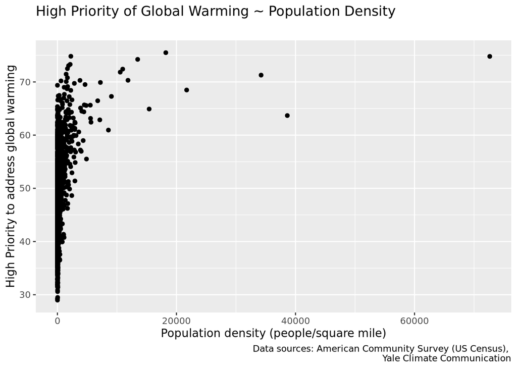

```r
ggplot(data=join.df, aes(x=`Population Density (Per Sq. Mile)`, y=priority))+
  geom_point()+
  labs(title = "High Priority of Global Warming ~ Population Density",
       subtitle = "",
       caption = "Data sources: American Community Survey (US Census), \n Yale Climate Communication")+
  xlab("Population density (people/square mile)")+
  ylab("High Priority to address global warming")
```

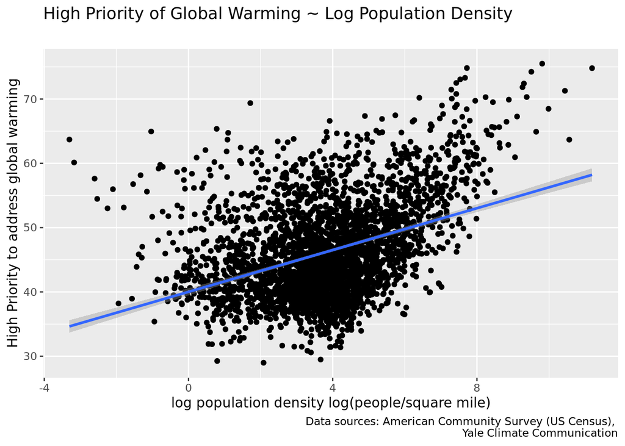

```r
ggplot(data=join.df, aes(x=`log.pop.dens`, y=priority))+
  geom_point()+
  geom_smooth(method="lm")+
  labs(title = "High Priority of Global Warming ~ Log Population Density",
       subtitle = "",
       caption = "Data sources: American Community Survey (US Census), \n Yale Climate Communication")+
  xlab("log population density log(people/square mile)")+
  ylab("High Priority to address global warming")
```

**Q1: Discuss the two scatterplots above.** The raw data is positively skewed so it violates the assumption 1 while the log data is well- scattered and shows linear relation between population density and priority global warning.

In the chunk below, run a linear model that is appropriate based on scatterplots above. Name the model model.1. Be sure that your X and Y are correctly placed in the lm() function.

```r
model.1<-lm(priority~log.pop.dens, data=join.df)
summary(model.1)
```

```
##
## Call:
## lm(formula = priority ~ log.pop.dens, data = join.df)
##
## Residuals:
##     Min      1Q  Median      3Q     Max
## -16.482  -4.789  -1.071   3.853  29.056
##
## Coefficients:
##              Estimate Std. Error t value Pr(>|t|)
## (Intercept)   40.0137     0.2831  141.32   <2e-16 ***
## log.pop.dens   1.6258     0.0676   24.05   <2e-16 ***
## ---
## Signif. codes:  0 '***' 0.001 '**' 0.01 '*' 0.05 '.' 0.1 ' ' 1
##
## Residual standard error: 6.842 on 3142 degrees of freedom
## Multiple R-squared:  0.1555, Adjusted R-squared:  0.1552
## F-statistic: 578.4 on 1 and 3142 DF,  p-value: < 2.2e-16
```

**Q2: Interpret the estimate on log.pop.dens and its statistical significance. Be clear about the null hypothesis.** 1% change of population density is associated with an increase in predicted prioritization of climate change by 0.016. (When we do log, we have to times 0.01 to beta->case 1) The null hypothesis is that logged population density and the priority regarding high priority of global warming has no correlation(The beta is 0). According to the P value(P <0.0001), we can reject the null hypothesis so there is correlation between variables.

**Q3: Interpret the R-squared value.** The r square shows it only explains 15% of the prioritization of climate change.

Run the chunk below, use the plot() function on the model object to get the Residuals vs Fitted Plot

**Q4: Discuss the residual vs fitted plot in terms of the assumptions of OLS.**

The red line would be flatted to meet the assumption 1 but it violates this assumption. In terms of homoscedasticity,data are clustered in the range of 40 to 50 so it also violets the homoscedasticity condition. In terms of Independence condition, it may have spatial auto correlation in our residuals.

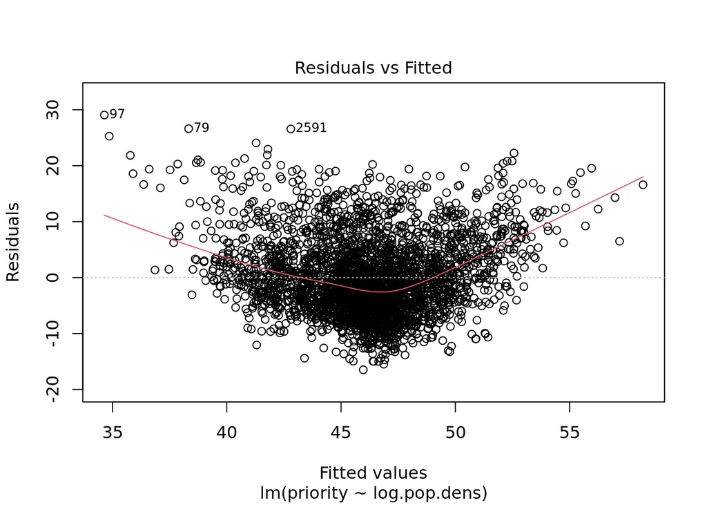

```r
plot(model.1,1)
```

The chunk below develops a scatterplot filters for log population density that are small (<0) and have high priority re global warming.

**Q5: Interpret the scatterplot below.** Under predicting their common things in low population density such as Alaska because we are using the population density indicating that we have omitted variable.

```r
low.df<-join.df%>%
  filter(log.pop.dens<0 & priority > 50)%>%
  arrange(log.pop.dens)
low.df
```

| state | Area Name | Qualifying Name | geoid | Total Population | Population Density (Per Sq. Mile) | Average Family Income (In 2022 Inflation Adjusted Dollars) | Average Commute to Work (In Min) | geotype | geoname | gwvoteimp | priority | log.pop.dens |
| --- | --- | --- | --- | --- | --- | --- | --- | --- | --- | --- | --- | --- |
| ak | Yukon-Koyukuk Census Area | Yukon-Koyukuk Census Area, Alaska | 2290 | 5355 | 0.03678502 | 75386.76 | 9 | county | Yukon-Koyukuk Census Area, Alaska | 63.42 | 63.70 | -3.30266458 |
| ak | Lake and Peninsula Borough | Lake and Peninsula Borough, Alaska | 2164 | 999 | 0.04191872 | 76035.39 | 7 | county | Lake And Peninsula Borough, Alaska | 58.58 | 60.13 | -3.17202277 |
| ak | Yakutat City and Borough | Yakutat City and Borough, Alaska | 2282 | 564 | 0.07398397 | 93774.38 | 5 | county | Yakutat City And Borough, Alaska | 57.39 | 57.62 | -2.60390683 |
| tx | Kenedy County | Kenedy County, Texas | 48261 | 116 | 0.07953039 | 56413.16 | NA | county | Kenedy County, Texas | 54.08 | 54.47 | -2.53161607 |
| ak | Copper River Census Area | Copper River Census Area, Alaska | 2066 | 2614 | 0.10586370 | 110266.88 | 28 | county | Copper River Census Area, Alaska | 55.37 | 53.00 | -2.24560286 |
| ak | North Slope Borough | North Slope Borough, Alaska | 2185 | 10924 | 0.12298530 | 117542.38 | 8 | county | North Slope Borough, Alaska | 61.54 | 55.98 | -2.09569044 |
| ak | Denali Borough | Denali Borough, Alaska | 2068 | 2101 | 0.16620460 | 133879.80 | 15 | county | Denali Borough, Alaska | 63.23 | 53.13 | -1.79453572 |
| ak | Northwest Arctic Borough | Northwest Arctic Borough, Alaska | 2188 | 7682 | 0.21540360 | 98000.08 | 7 | county | Northwest Arctic Borough, Alaska | 56.76 | 56.77 | -1.53524180 |
| ak | Dillingham Census Area | Dillingham Census Area, Alaska | 2070 | 4854 | 0.26475410 | 86464.94 | 9 | county | Dillingham Census Area, Alaska | 57.56 | 58.15 | -1.32895381 |
| nm | Harding County | Harding County, New Mexico | 35021 | 671 | 0.31569360 | 284221.60 | 25 | county | Harding County, New Mexico | 55.97 | 55.60 | -1.15298316 |

[output cut: 14 more lines]

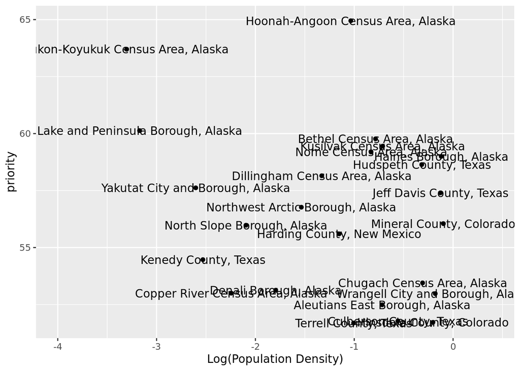

```r
ggplot(data=low.df, aes(x=log.pop.dens, y=priority))+
  geom_point()+
  geom_text(aes(label=`Qualifying Name`))+
  xlim(-4, 0.4)+
  xlab("Log(Population Density)")
```

```r
high.df<-join.df%>%
  filter(log.pop.dens>8 & priority > 60)%>%
  arrange(log.pop.dens)
high.df
```

| state | Area Name | Qualifying Name | geoid | Total Population | Population Density (Per Sq. Mile) | Average Family Income (In 2022 Inflation Adjusted Dollars) | Average Commute to Work (In Min) | geotype | geoname | gwvoteimp | priority | log.pop.dens |
| --- | --- | --- | --- | --- | --- | --- | --- | --- | --- | --- | --- | --- |
| tx | Dallas County | Dallas County, Texas | 48113 | 2604053 | 2982.390 | 119045.96 | 27 | county | Dallas County, Texas | 71.53 | 62.29 | 8.000480 |
| mn | Ramsey County | Ramsey County, Minnesota | 27123 | 547202 | 3594.118 | 131750.20 | 23 | county | Ramsey County, Minnesota | 59.22 | 60.60 | 8.187054 |
| va | Richmond city | Richmond city, Virginia | 51760 | 227171 | 3790.921 | 122276.12 | 22 | county | Richmond City, Virginia | 67.42 | 70.29 | 8.240364 |
| va | Fairfax city | Fairfax city, Virginia | 51600 | 24242 | 3884.359 | 186610.53 | 28 | county | Fairfax City, Virginia | 63.13 | 65.10 | 8.264713 |
| nj | Bergen County | Bergen County, New Jersey | 34003 | 953243 | 4094.894 | 188367.46 | 32 | county | Bergen County, New Jersey | 62.25 | 64.50 | 8.317496 |
| va | Norfolk city | Norfolk city, Virginia | 51710 | 236973 | 4448.115 | 99884.55 | 23 | county | Norfolk City, Virginia | 57.57 | 64.38 | 8.400236 |
| va | Charlottesville city | Charlottesville city, Virginia | 51540 | 46289 | 4518.172 | 149460.34 | 17 | county | Charlottesville City, Virginia | 64.49 | 65.68 | 8.415863 |
| co | Denver County | Denver County, Colorado | 8031 | 710800 | 4643.502 | 154887.44 | 25 | county | Denver County, Colorado | 65.20 | 69.51 | 8.443224 |
| mo | St. Louis city | St. Louis city, Missouri | 29510 | 298018 | 4828.575 | 96794.53 | 23 | county | St. Louis City, Missouri | 59.95 | 65.57 | 8.482307 |
| il | Cook County | Cook County, Illinois | 17031 | 5225367 | 5529.932 | 137032.81 | 32 | county | Cook County, Illinois | 65.09 | 65.63 | 8.617931 |

[output cut: 17 more lines]